# Old School Visualization

02 Loctober 2020

## Welcome!

### SCR Week 05

## QA? Any questions?

- Asking questions via rteam@stat.leidenuniv.nl
- is good feedback for us to see how you’re doing
- Topic for explanation in the Live Coding XXL

## Today’s topics

Visualization: functions based one of the base packages: `graphics`.  
- `demo(graphics)`

Chapter 12 of the [book](https://surfdrive.surf.nl/files/index.php/s/9dMDeZMORjTELgg) by Norman Matloff

Visualization for (and of) Statistics

## (Tentative) Schedule Today

**09.15 - 10.00**: old `R` school visualizations  
- talking / live coding / quiz

**10.15 - 11.00**: - mainly (if not only) exercises

**11.15 - 12.00**: + of (random) distributions  
- talking / live coding / quiz / exercises

**12.15 - 13.00**: XX Live coding (on request)  
- Exercise 5.4 last week

## Visualization

## Visualization

Visualization: show data (or other numbers) as a graph

Possible goals:

- exploration: find patterns in the data
- explanation: tell a message
- obfuscation: lie with statistics ([**not ok**](https://youtu.be/M1owcncKCHg))

## Example Exploration

```r
set.seed(20171002)
N <- 1e4
x <- runif(N)
y <- x^2 + rnorm(N, sd=0.25)
```

## Example Exploration

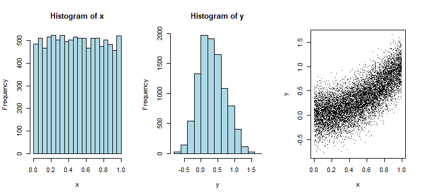

```r
par(mfrow=c(1, 3))
hist(x, col='lightblue')
hist(y, col='lightblue')
plot(x, y, pch = ".")
```

## Example ‘Explanation’

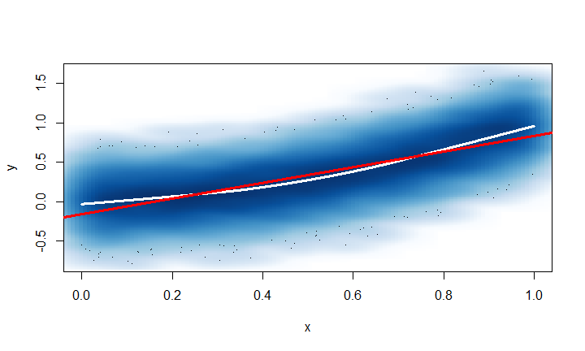

```r
smoothScatter(x, y)
lines(lowess(y~x), lwd=3, col='white')
abline(lm(y~x), col='red', lwd=3)
```

## Obfuscation

Is any of these plots based on Normal Data?

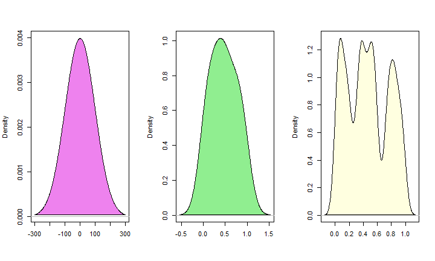

## Obfuscation

```r
set.seed(20171002)
x1 <- runif(100)
```

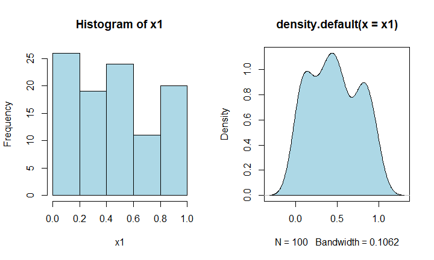

## Good habits for Visualization

Very opinionated…. We think the goal should be to tell a story, one that is ‘true’ and does not obfuscate.

1. Aesthetics are necessary, but secondary
2. Try to to make graphs as clear as possible (KISS)
3. Although the digital world is growing, keep in mind the printing and publishing

## Lost in translation

[figure not shown]

Programming requires you to translate between code and purpose

Sometimes easy: `hist()`

Sometimes it’s harder: `contour()`

The function `help()` and operator `?` are your friends (the WWW as well).

## `graphics`

[figure not shown]

## Conventional static plots

- `barplot()`
- `boxplot()`
- `dotchart()`
- `hist()`
- `pie()`
- `persp()`
- **But most importantly:** `graphics::plot()` and `base::plot()`

## helpfile `base::plot()`

**Usage**

`plot(x, y, ...)`

**Arguments**

`x`: the coordinates of points in the plot. Alternatively, a single plotting structure, function or any `R` object with a plot method can be provided.

`y`: the y coordinates of points in the plot, optional if x is an appropriate structure.

`...`: Arguments to be passed to methods, such as graphical parameters (see `par()`).

## The input of `plot()`

```r
methods(plot)
```

```
##  [1] plot.acf*           plot.data.frame*    plot.decomposed.ts*
##  [4] plot.default        plot.dendrogram*    plot.density*
##  [7] plot.ecdf           plot.factor*        plot.formula*
## [10] plot.function       plot.hclust*        plot.histogram*
## [13] plot.HoltWinters*   plot.isoreg*        plot.lm*
## [16] plot.medpolish*     plot.mlm*           plot.ppr*
## [19] plot.prcomp*        plot.princomp*      plot.profile.nls*
## [22] plot.raster*        plot.spec*          plot.stepfun
## [25] plot.stl*           plot.table*         plot.ts
## [28] plot.tskernel*      plot.TukeyHSD*
## see '?methods' for accessing help and source code
```

## What about `plot.<method>*`

Functions with an asterisk are nonvisible. Typing, for example, `plot.formula` gives you an error.

```r
graphics:::plot.formula # using the ::: operator
```

or

```r
getAnywhere(plot.formula)
```

## Live coding 1

### `plot()` and `par()`

[figure not shown]

## ?

## plots and parameterization

Some plotting procedures require you to choose input parameters / arguments

E.g.:

- `hist()`: `breaks`
- `density()`: `bw`

## `hist()`: `breaks` arguments

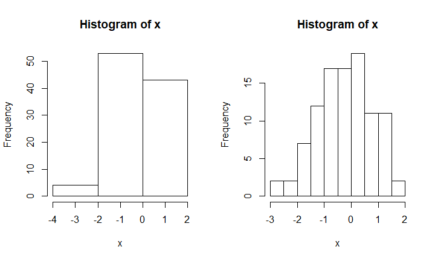

```r
x <- rnorm(100)
par(mfrow=c(1, 2))
hist(x, 3)
hist(x, breaks="FD")
```

```r
par(mfrow=c(1, 1))
```

## `density`: `bw` argument

> The default, “nrd0”, has remained the default for historical and compatibility reasons, rather than as a general recommendation, where e.g., “SJ” would rather fit, see also Venables and Ripley (2002).

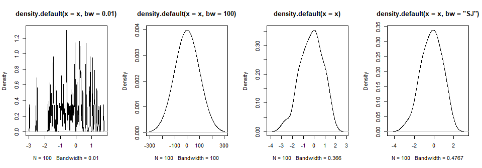

## `graphics` parameters and functions

line:  
- functions: `lines()`, `abline()`, `curve()`, `segments()`  
- arguments: `lty`, `type = "l"`, `lwd`

points:  
- functions: `points()`  
- arguments: `pch`, `type = "p"`, `cex.pch`

functions for (filled) surfaces: `rect()`, `polygon()`, `segments()`

… and so on. For functions check `help(package = "graphics")`, for arguments check `?par`.

## Exercises: Part 1

[figure not shown]

## Distributions (and Visualization)

[figure not shown]

## Refresher? Probability distributions

- `dnorm()`
- `pnorm()`
- `qnorm()`

`pnorm()` and `qnorm()` are quite similar, but exactly opposite: cumulative density and inverse cumulative density

Similarly: `df()`, `dt()`, `dunif()`, `dlnorm()`, `dchisq()`, `dexp()`, etc

## Example when using for `dnorm()`: log likelihood

Recall

\[\log(AB) = \log(A) + \log(B)\]

and therefore we have

\[\log(\prod_{i}^{N}\phi(x_{i})) = \sum_{i}^{N}\log(\phi(x_{i})))\]

We can apply this in `R`, using the `dnorm` function:

```r
sum(dnorm(x, log=T))
```

Setting `log=T`, and using `sum` instead of `prod` is often a good idea as it is numerically more stable

## Quiz

## Refresher? Probability distributions

- `dnorm()`
- `pnorm()`
- `qnorm()`

`pnorm()` and `qnorm()` are quite similar, but exactly opposite: cumulative density and inverse cumulative density

Similarly: `df()`, `dt()`, `dunif()`, `dlnorm()`, `dchisq()`, `dexp()`, etc

## Random sampling

## Sampling from Statistical Distributions

`R` allows us to randomly sample from most distributions

Consists of two important components:

- A random number generator
- A way to convert these numbers into whatever type of numbers you are interested in

**In practice:**

A random number generator that samples a value with a uniform distribution in a particular interval

Then use one of many tricks to convert these into a value distributed according to some distribution

## Example a.k.a. Inverse CDF trick

E.g.: `rnorm`, `runif`

```r
set.seed(191011)
rnorm(1)
```

```
## [1] -0.02926516
```

```r
set.seed(191011)
qnorm(runif(1))
```

```
## [1] -0.02926516
```

Tells us that, probably, deep down the functions get their numbers from the same generator

[figure not shown]

## Random number generator

The random number generator in R is ‘pseudo’ random: starting from a given state inside the generator, results are always the same

`set.seed` allows us to set a state!

Check `.Random.seed` for the *actual state* the generator is currently in

For the default random generator, there are many more states than seeds! (about 624^(2^31) times as much in a 32-bits version)

## Recap

for this course just be aware that

- Numbers are ‘only’ pseudo-random, and that there is something as a seed, which users can set
- Numbers are close enough to actually random that you may act upon them *as if* they are

## Quiz?

## Visualization of Density

## `plot.density`

We have the variables:

```r
set.seed(123)
x1 <- rnorm(1e4)
x2 <- rnorm(1e4)
```

## `plot.function` of x1 - x2

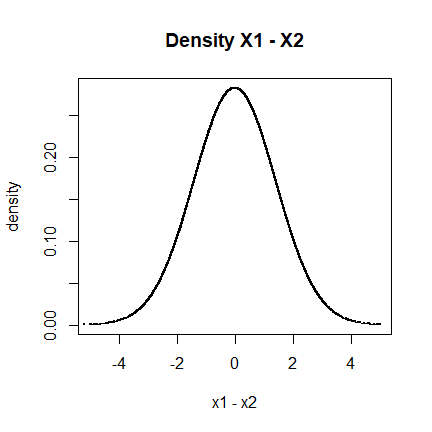

```r
dnorm2 <- function(x) {
  dnorm(x, sd = sqrt(2))
}
plot(dnorm2,
  xlim = c(-5, 5),
  xlab = "x1 - x2",
  ylab = "density"
)
points(
  x = x1 - x2,
  y = dnorm2(x1 - x2),
  pch = 20, cex = 0.5
)
title(main = "Density X1 - X2")
```

## `hist` and `density` plots

One of the many ways:

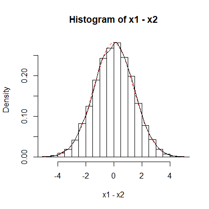

```r
hg.x1mx2 <- hist(x1 - x2,
    xlim = c(-5, 5),
    freq = FALSE,
    xpd = TRUE
)
curve(expr = dnorm2,
      add = TRUE,
      col = 'red',
      lty = 2
)
ds.x1mx2 <- density(x1 - x2)
lines(ds.x1mx2)
```

## `qqplot`

From the helpfile of `hist`: “Comparing data with a model distribution should be done with `qqplot()`!”

Compares empirical ‘quantiles’ with theoretical quantiles

If perfectly similar: points will lie on a line

In practice: random jitter, along a straight line is ‘good’

## `qqplot()`

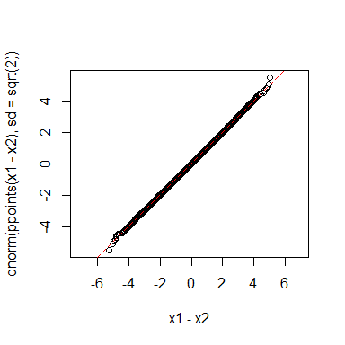

```r
qqplot(x1 - x2, qnorm(ppoints(x1 - x2), sd = sqrt(2)), asp = 1)
abline(0, 1, col = 2, lty = 2)
```

## ‘3D’ plots

## `contour`: contourplot!

Like a map of land: contourlines are heightlines.

Thus also works beautifully if plot surface behaves like a map.

e.g. `volcano`

## `contour(volcano)`

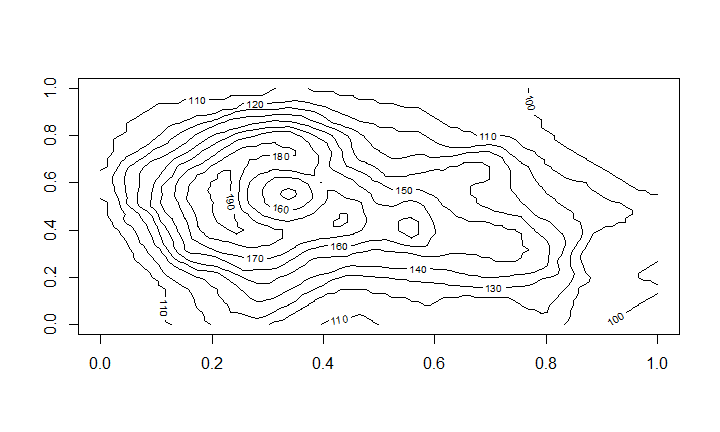

```r
data(volcano)
contour(volcano)
```

## `contour(my_LogLikhds)`

E.g. a check for one single mode:

```r
set.seed(20181012)
X1 <- scale(rnorm(1e4))
my_mus <- seq(-1, 1, length.out = 50)
my_sig <- seq(0.5, 1.5, length.out = 50)
```

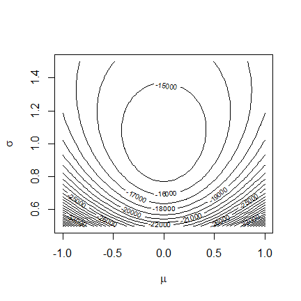

```r
contour(
  x = my_mus,
  y = my_sig,
  z = my_LogLikhds,
  xlab = bquote(mu),
  ylab = bquote(sigma),
  nlevels = 25
)
```

## The bivariate density of X1 - X2, X1 + X2?

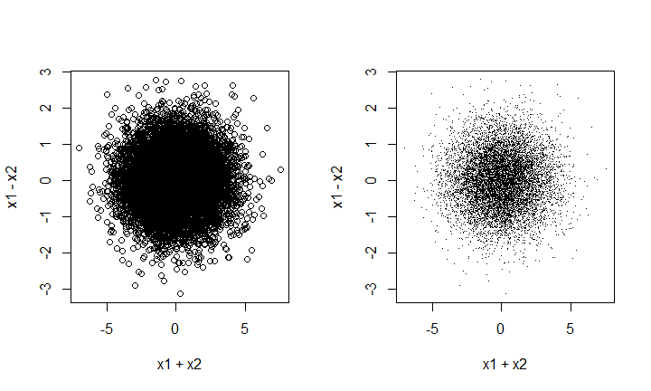

```r
op <- par(mfrow = c(1, 2))
plot(y = x1 - x2, x = x1 + x2)
plot(y = x1 - x2, x = x1 + x2, pch = ".")
```

## The bivariate density of X1 - X2, X1 + X2?

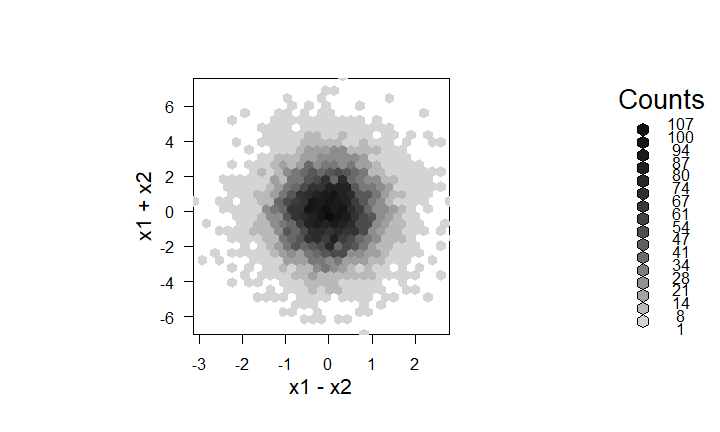

```r
plot(hexbin(x1 - x2, x1 + x2))
```

## `persp`: a more traditional 3d plot

Like a scatterplot, but in 3D, instead of 2D.

Requires an extra dimension of consideration: viewpoint

With \(x = X_1 - X_2\) an \(y = X_1 + X_2\), and knowing that:

- \(X_1 \sim N(0, 1)\)
- \(X_2 \sim N(0, 1)\)

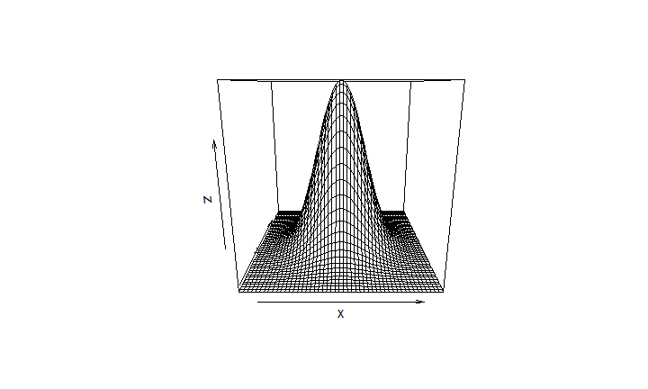

```r
dbvnorm <- function(x,y) {
  cnst <- (1 / (2 * pi * 2))
  nssd <- exp(-.5 * (x^2 + y^2) / 2)
  z <- cnst * nssd
  return(z)
}
y <- x <- seq(-5, 5, length = 50)
z <- outer(x, y, dbvnorm)
persp(x, y, z) # default persp
```

## Plot bivariate normal density

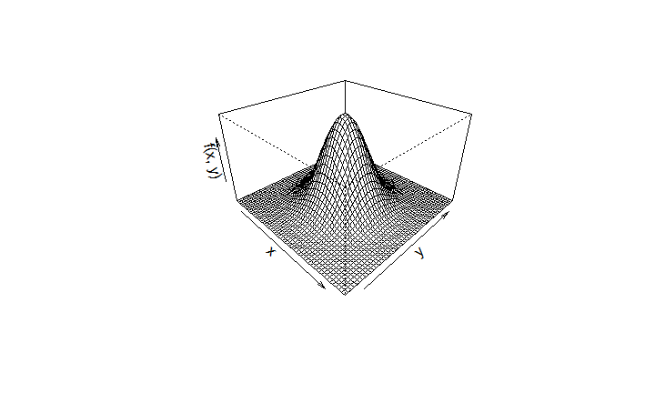

```r
persp(x, y, z, theta = 45, phi = 30, expand = 0.6,
  xlab = "x", ylab = "y", zlab = "f(x, y)")
```

## `persp`: a different viewpoint

[figure not shown]

```r
persp(x, y, z, theta = 45, phi = 0, expand = 0.6,
  ltheta = 120, shade = 0.75, ticktype = "detailed",
  xlab = "x", ylab = "y", zlab = "f(x, y)")
```

## Exercises part 2

[figure not shown]

## Outro

## Visualization with Mathematical Annotation

Definitely helpful for your assignments, internship, thesis, or later in life is `bquote()` in combination with `?plotmath`.

```r
example(plotmath)
demo(plotmath)
```

## Choice of graphs

Most plots have a particular purpose; stick to that purpose!

With `graphics` package you have all the flexibility. Aesthetics however….

Some people prefer

- `lattice`
- `ggplot2` (next week!)
- [`d3`](https://d3js.org)(`htmlwdigets` and `shiny`)
- or (m)any of the other packages out there

Advice: rebuild and tweak code from others (but do not steal!):  
- http://www.intro-stats.com  
- http://www.datavis.ca/gallery/visual-explanation.php

## Recap

master the core function: `graphics::plot`

adapt layout using graphical parameters from `graphics:par`

apply functions from the `graphics` package

## @12.15 XXL Live Coding

### Week 04 bits of Exercise 5.4

[figure not shown]

## See you Next Week

### On to the tidyverse: `ggplot2`